# Pratical HM 3

Next, a different **dense value** was tested.

```python
%%time

np.random.seed(1)
tf.random.set_seed(1)

model_multi_8E = Sequential([
    Conv2D(filters=16, kernel_size=(3, 3), padding="same", activation="relu", input_shape=x_multi_train.shape[1:]),
    MaxPooling2D(pool_size=(2, 2)),
    Conv2D(filters=32, kernel_size=(3, 3), padding="same", activation="relu"),
    MaxPooling2D(pool_size=(2, 2)),
    Conv2D(filters=64, kernel_size=(3, 3), padding="same", activation="relu"),
    MaxPooling2D(pool_size=(2, 2)),
    Conv2D(filters=128, kernel_size=(3, 3), padding="same", activation="relu"),
    MaxPooling2D(pool_size=(2, 2)),
    Flatten(),
    Dropout(rate= 0.3),
    #increase Dense layer from 64 to 128
    Dense(units=128, activation="relu"),
    Dense(units=12, activation="softmax")])

model_multi_8E.compile(loss='categorical_crossentropy',
                  optimizer='rmsprop',
                  metrics=['accuracy'])

history_multi_8E = model_multi_8E.fit(x_multi_train, y_multi_train,
            epochs=10,
            batch_size=16,
            validation_split=0.2,
            verbose=0)

train_score_multi_8E = model_multi_8E.evaluate(x_multi_train, y_multi_train, verbose=0)
test_score_multi_8E = model_multi_8E.evaluate(x_multi_test, y_multi_test, verbose=0)

print("Training Accuracy: {:.2f}%".format(train_score_multi_8E[1] * 100))
print("Training Error: {:.2f}%".format((1 - train_score_multi_8E[1]) * 100))
print("Test Accuracy: {:.2f}%".format(test_score_multi_8E[1] * 100))
print("Test Error: {:.2f}%".format((1 - test_score_multi_8E[1]) * 100))
```

```
Training Accuracy: 70.56%
Training Error: 29.44%
Test Accuracy: 44.03%
Test Error: 55.97%
CPU times: user 11min 6s, sys: 55.8 s, total: 12min 2s
Wall time: 2min 7s
```

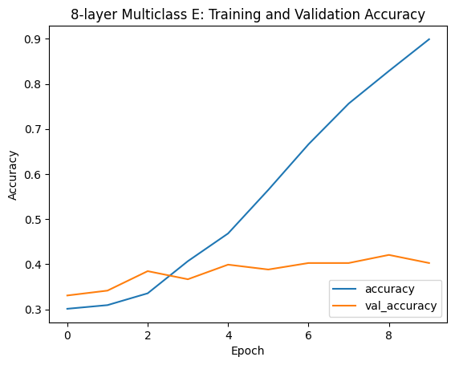

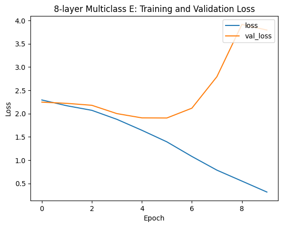

```python
plt.plot(history_multi_8E.history["accuracy"])
plt.plot(history_multi_8E.history["val_accuracy"])
plt.xlabel("Epoch")
plt.ylabel("Accuracy")
plt.legend(['accuracy', 'val_accuracy'], loc='lower right')
plt.title("8-layer Multiclass E: Training and Validation Accuracy")
plt.show()

plt.plot(history_multi_8E.history["loss"])
plt.plot(history_multi_8E.history["val_loss"])
plt.xlabel("Epoch")
plt.ylabel("Loss")
plt.legend(['loss', 'val_loss'], loc='upper right')
plt.title("8-layer Multiclass E: Training and Validation Loss")
plt.show()
```

```python
%%time
#larger filter numbers
np.random.seed(1)
tf.random.set_seed(1)

model_multi_8F = Sequential([
    Conv2D(filters=32, kernel_size=(3, 3), padding="same", activation="relu", input_shape=x_multi_train.shape[1:]),
    MaxPooling2D(pool_size=(2, 2)),
    Conv2D(filters=64, kernel_size=(3, 3), padding="same", activation="relu"),
    MaxPooling2D(pool_size=(2, 2)),
    Conv2D(filters=128, kernel_size=(3, 3), padding="same", activation="relu"),
    MaxPooling2D(pool_size=(2, 2)),
    Conv2D(filters=256, kernel_size=(3, 3), padding="same", activation="relu"),
    MaxPooling2D(pool_size=(2, 2)),
    Flatten(),
    Dropout(rate= 0.3),
    Dense(units=64, activation="relu"),
    Dense(units=12, activation="softmax")])

model_multi_8F.compile(loss='categorical_crossentropy',
                  optimizer='rmsprop',
                  metrics=['accuracy'])

history_multi_8F = model_multi_8F.fit(x_multi_train, y_multi_train,
            epochs=10,
            batch_size=16,
            validation_split=0.2,
            verbose=0)

train_score_multi_8F = model_multi_8F.evaluate(x_multi_train, y_multi_train, verbose=0)
test_score_multi_8F = model_multi_8F.evaluate(x_multi_test, y_multi_test, verbose=0)

print("Training Accuracy: {:.2f}%".format(train_score_multi_8F[1] * 100))
print("Training Error: {:.2f}%".format((1 - train_score_multi_8F[1]) * 100))
print("Test Accuracy: {:.2f}%".format(test_score_multi_8F[1] * 100))
print("Test Error: {:.2f}%".format((1 - test_score_multi_8F[1]) * 100))
```

```
Training Accuracy: 55.19%
Training Error: 44.81%
Test Accuracy: 45.21%
Test Error: 54.79%
CPU times: user 29min 27s, sys: 2min 23s, total: 31min 50s
Wall time: 4min 57s
```

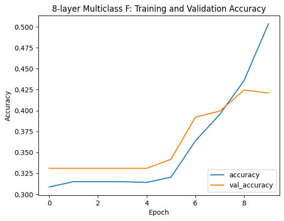

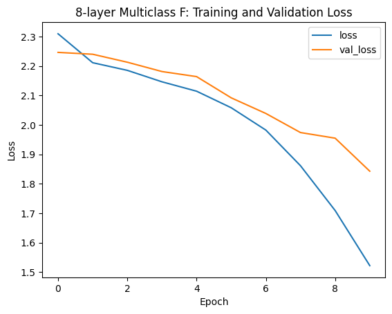

```python
plt.plot(history_multi_8F.history["accuracy"])
plt.plot(history_multi_8F.history["val_accuracy"])
plt.xlabel("Epoch")
plt.ylabel("Accuracy")
plt.legend(['accuracy', 'val_accuracy'], loc='lower right')
plt.title("8-layer Multiclass F: Training and Validation Accuracy")
plt.show()

plt.plot(history_multi_8F.history["loss"])
plt.plot(history_multi_8F.history["val_loss"])
plt.xlabel("Epoch")
plt.ylabel("Loss")
plt.legend(['loss', 'val_loss'], loc='upper right')
plt.title("8-layer Multiclass F: Training and Validation Loss")
plt.show()
```

Increasing the number of filters did not improve test accuracy (corresponding to a test error of 54.79%), the accuracy and loss curves demonstrated signs of underfitting.

Another issue with this dataset is the class imbalance, with *houspa* has 630 soectrograms and *norfli* has only 37 spectrograms. I also tested class weighting to address the imbalance across species.

```python
class_weights_array = compute_class_weight(
    class_weight="balanced",
    classes=np.unique(y_multi),
    y=y_multi)

class_weights = dict(enumerate(class_weights_array))
print(class_weights)
```

[output not shown]

```python
%%time

np.random.seed(1)
tf.random.set_seed(1)

model_multi_8G = Sequential([
    Conv2D(filters=16, kernel_size=(3, 3), padding="same", activation="relu", input_shape=x_multi_train.shape[1:]),
    MaxPooling2D(pool_size=(2, 2)),
    Conv2D(filters=32, kernel_size=(3, 3), padding="same", activation="relu"),
    MaxPooling2D(pool_size=(2, 2)),
    Conv2D(filters=64, kernel_size=(3, 3), padding="same", activation="relu"),
    MaxPooling2D(pool_size=(2, 2)),
    Conv2D(filters=128, kernel_size=(3, 3), padding="same", activation="relu"),
    MaxPooling2D(pool_size=(2, 2)),
    Flatten(),
    Dropout(rate= 0.3),
    Dense(units=64, activation="relu"),
    Dense(units=12, activation="softmax")])

model_multi_8G.compile(loss='categorical_crossentropy',
                  optimizer='rmsprop',
                  metrics=['accuracy'])

history_multi_8G = model_multi_8G.fit(x_multi_train, y_multi_train,
            epochs=10,
            batch_size=16,
            validation_split=0.2,
            #add class weights to address class imbalance
            class_weight=class_weights,
            verbose=0)

train_score_multi_8G = model_multi_8G.evaluate(x_multi_train, y_multi_train, verbose=0)
test_score_multi_8G = model_multi_8G.evaluate(x_multi_test, y_multi_test, verbose=0)

print("Training Accuracy: {:.2f}%".format(train_score_multi_8G[1] * 100))
print("Training Error: {:.2f}%".format((1 - train_score_multi_8G[1]) * 100))
print("Test Accuracy: {:.2f}%".format(test_score_multi_8G[1] * 100))
print("Test Error: {:.2f}%".format((1 - test_score_multi_8G[1]) * 100))
```

```
Training Accuracy: 4.62%
Training Error: 95.38%
Test Accuracy: 4.54%
Test Error: 95.46%
CPU times: user 10min 43s, sys: 49.5 s, total: 11min 33s
Wall time: 1min 59s
```

However, applying the class weighting substantially worsened the overall test accuracy (corresponding to a test error of 95.46%). So it was not used in the final model.

Although overfitting issue was not eliminated, original Model 8 was selected as the final multiclass CNN model because it provude the lowest test error (53.11%) among all tested models. The final model was a 8-layer CNN with four convolution-pooling blocks, using filter sizes of 16/32/64/128 ReLU activations, dropout of 0.3, a dense layer of 64 units, and a 12-unit soft max output layer for the multiclass species predictions.

```
19/19 ━━━━━━━━━━━━━━━━━━━━ 2s 79ms/step
```

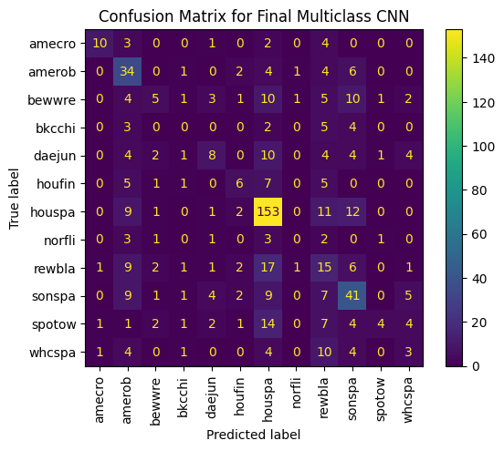

```python
#create confusion matrix for model_multi_8
y_pred_prob = model_multi_8.predict(x_multi_test)
y_pred = np.argmax(y_pred_prob, axis=1)
y_true = np.argmax(y_multi_test, axis=1)
cm = confusion_matrix(y_true, y_pred)

#plot confusion matrix
disp = ConfusionMatrixDisplay(
    confusion_matrix=cm,
    display_labels=species_key_from_list)

disp.plot(xticks_rotation=90)
plt.title("Confusion Matrix for Final Multiclass CNN")
plt.show()
```

```python
#per-class precision, recall, and F1-score
print(classification_report(
    y_true,
    y_pred,
    target_names=species_key_from_list))
```

```
              precision    recall  f1-score   support

      amecro       0.77      0.50      0.61        20
      amerob       0.39      0.65      0.49        52
      bewwre       0.33      0.12      0.17        43
      bkcchi       0.00      0.00      0.00        14
      daejun       0.38      0.21      0.27        38
      houfin       0.38      0.24      0.29        25
      houspa       0.65      0.81      0.72       189
      norfli       0.00      0.00      0.00        11
      rewbla       0.19      0.27      0.22        56
      sonspa       0.45      0.52      0.48        79
      spotow       0.57      0.10      0.17        41
      whcspa       0.16      0.11      0.13        27

    accuracy                           0.47       595
   macro avg       0.36      0.29      0.30       595
weighted avg       0.45      0.47      0.44       595
```

Based on the classification report, the species predicted most successtuly was *houspa*, which had the highest recall of 0.81 (81% of the true houspa spectrograms in the test set were correctly classified).houspa also had the highest F1-score of 0.72, suggesting that it had the best balance between precision and recall among the 12 species. The species that were most challenging to predict were *bkcchi* and *norfli* (both have a recall value of 0; meaning non of the true spectrograms in the test set from these species were correctly classified). The strong performance for *houspa* may partly due to its larger number of training examples, while the poor performance for *bkcchi* and *norfli* may be related to their smaller sample size. The confusion matrix showed that *rewbla* was often misclassified as *houspa*, with 17 *rewbla* spectrograms were mistakenly classified as *houspa*. This suggested that the model had difficulty distinguishing *rebla* from the more common *houspa* class. Other frequent misclassifications included true *spotow* predicted as *houspa* 14 times, true *houspa* predicted as *sonspa* 12 times, and true *houspa* predicted as *rewbla* 11 times.

#### External Test Data:

Each of 3 test clips provided are of raw sound data (mp3), some of which contain more than one bird call. Convert them using the methodology described below, and use your 12-species network to predict which birds are calling-- clearly state your prediction of each of the three clips in a table in your results section. Which clips do you think contain more than one bird and why? Make sure to justify your reasoning with a plot or data.

```python
#Load the mp3 file of test1
file_path = "/Users/helenliu/Downloads/test1.mp3"
y_audio, sr = librosa.load(file_path)
print("Sample rate:", sr)
print("Audio length (seconds):", len(y_audio) / sr)

#split the audio into 3-second clips
window_seconds = 3
window_length = window_seconds * sr
test1_clips = []
for start in range(0, len(y_audio)-window_length+1, window_length):
    end = start + window_length
    small_clip = y_audio[start:end]
    test1_clips.append(small_clip)

print("Number of 3-second clips:", len(test1_clips))
```

```
Sample rate: 22050
Audio length (seconds): 23.275102040816325
Number of 3-second clips: 7
```

```python
#create spectrograms for each clip
test1_specs = []
for i, clip in enumerate(test1_clips):
    spec = librosa.feature.melspectrogram(
        y=clip,
        sr=sr,
        hop_length=128,
        win_length=512)
    spec_db = librosa.power_to_db(spec, ref=np.max)
    test1_specs.append(spec_db)
    print("Clip", i + 1, "spectrogram shape:", spec_db.shape)
```

```
Clip 1 spectrogram shape: (128, 517)
Clip 2 spectrogram shape: (128, 517)
Clip 3 spectrogram shape: (128, 517)
Clip 4 spectrogram shape: (128, 517)
Clip 5 spectrogram shape: (128, 517)
Clip 6 spectrogram shape: (128, 517)
Clip 7 spectrogram shape: (128, 517)
```

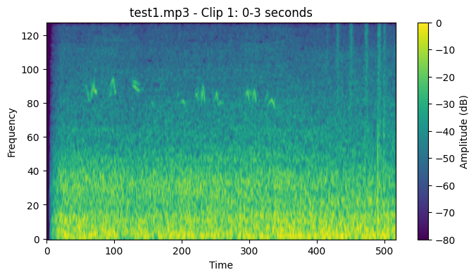

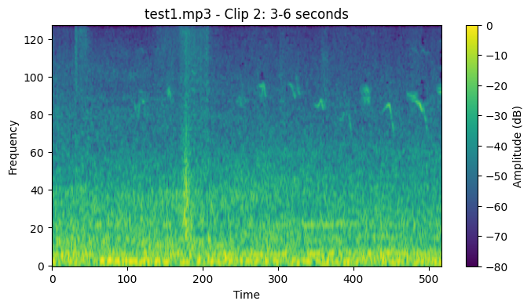

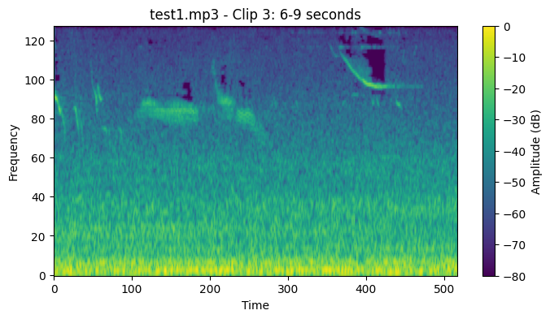

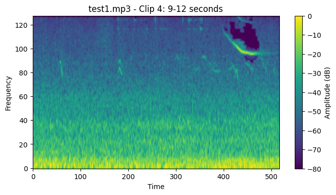

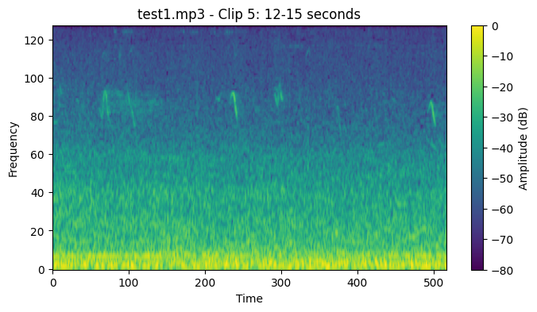

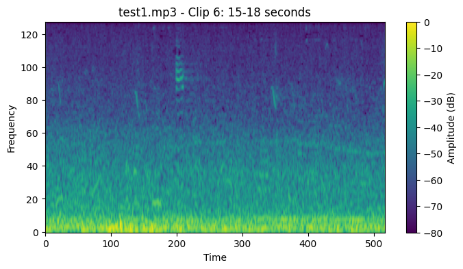

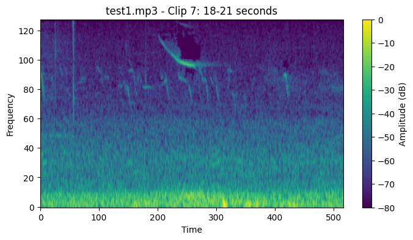

```python
#plot spectrograms
for i, spec_db in enumerate(test1_specs):
    plt.figure(figsize=(8, 4))
    plt.imshow(spec_db, aspect="auto", origin="lower")
    plt.title(f"test1.mp3 - Clip {i + 1}: {i*3}-{(i+1)*3} seconds")
    plt.xlabel("Time")
    plt.ylabel("Frequency")
    plt.colorbar(label="Amplitude (dB)")
    plt.show()
```

```python
#convert spectrograms
x_test1_external = np.array(test1_specs)
print("Before normalization:", x_test1_external.shape)

#normalize spectrograms to 0-1 range
x_test1_external_norm = []
for spec_db in x_test1_external:
    spec_norm = (spec_db - spec_db.min()) / (spec_db.max() - spec_db.min())
    x_test1_external_norm.append(spec_norm)
x_test1_external_norm = np.array(x_test1_external_norm)

#add channel dimension
x_test1_external_norm = x_test1_external_norm[..., np.newaxis]

print("CNN-ready shape:", x_test1_external_norm.shape)
```

```
Before normalization: (7, 128, 517)
CNN-ready shape: (7, 128, 517, 1)
```

```python
#predict each small clip with the final model
model_multi_final = model_multi_8
pred_prob_test1 = model_multi_final.predict(x_test1_external_norm)
pred_class_test1 = np.argmax(pred_prob_test1, axis=1)
pred_species_test1 = [species_key_from_list[i] for i in pred_class_test1]

for i, species in enumerate(pred_species_test1):
    print(f"Clip {i + 1}: {i*3}-{(i+1)*3} sec")
    print("Predicted species:", species)
    print("Probability:", pred_prob_test1[i, pred_class_test1[i]])
    print()
```

[output not shown]

Test clip 1 was predicted mostly as House Sparrow (houspa) and Red-winged Blackbird (rewbla), with moderate predicted probability across multiple windows. This suggested that test clip 1 may contain more than one bird species. However, Table 4 showed that House Sparrow (houspa) has a relatively high precision (65%) and Red-winged Blackbird (rewbla) has a low precision (19%), and confusion matrix in Figure 4 showed frequent confusion between these two species. Therefore, it is also possible that test clip 1 contains primarily one species (House Sparrow) but was sometimes misclassified as Red-winged Blackbird.

```
Sample rate: 22050
Audio length (seconds): 5.250612244897959
Number of clips: 2
Clip times: [(0.0, 3.0), (3.0, 5.250612244897959)]
Clip 1 spectrogram shape: (128, 517)
Clip 2 spectrogram shape: (128, 517)
```

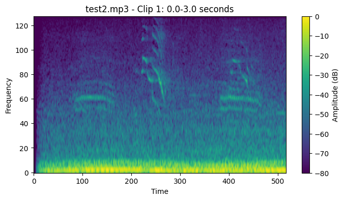

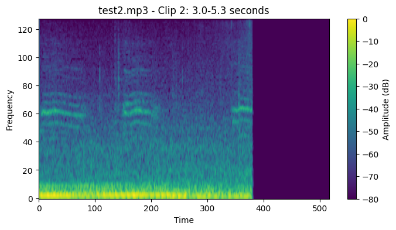

```
Before normalization: (2, 128, 517)
CNN-ready shape: (2, 128, 517, 1)
1/1 ━━━━━━━━━━━━━━━━━━━━ 0s 187ms/step
Clip 1: 0-3 sec
Predicted species: amerob
Probability: 0.5319152

Clip 2: 3-6 sec
Predicted species: rewbla
Probability: 0.6049736
```

```python
#Load the mp3 file of test2
file_path = "/Users/helenliu/Downloads/test2.mp3"
y_audio, sr = librosa.load(file_path)
print("Sample rate:", sr)
print("Audio length (seconds):", len(y_audio) / sr)

#split the audio into 3-second clips
window_seconds = 3
window_length = int(window_seconds * sr)
test2_clips = []
test2_times = []

start = 0

while start < len(y_audio):
    end = start + window_length
    small_clip = y_audio[start:end]
    # If this is the last leftover clip and it is shorter than 3 seconds,
    # pad it with silence so it has the same length as the training clips.
    if len(small_clip) < window_length:
        small_clip = np.pad(
            small_clip,
            (0, window_length - len(small_clip)),
            mode="constant")
    test2_clips.append(small_clip)
    test2_times.append((start / sr, min(end, len(y_audio)) / sr))

    start = end

print("Number of clips:", len(test2_clips))
print("Clip times:", test2_times)

#create spectrograms for each clip
test2_specs = []
for i, clip in enumerate(test2_clips):
    spec = librosa.feature.melspectrogram(
        y=clip,
        sr=sr,
        hop_length=128,
        win_length=512)
    spec_db = librosa.power_to_db(spec, ref=np.max)
    test2_specs.append(spec_db)
    print("Clip", i + 1, "spectrogram shape:", spec_db.shape)

    #plot spectrograms
for i, spec_db in enumerate(test2_specs):
    start_time, end_time = test2_times[i]
    plt.figure(figsize=(8, 4))
    plt.imshow(spec_db, aspect="auto", origin="lower")
    plt.title(f"test2.mp3 - Clip {i + 1}: {start_time:.1f}-{end_time:.1f} seconds")
    plt.xlabel("Time")
    plt.ylabel("Frequency")
    plt.colorbar(label="Amplitude (dB)")
    plt.show()

#convert spectrograms
x_test2_external = np.array(test2_specs)
print("Before normalization:", x_test2_external.shape)

#normalize spectrograms to 0-1 range
x_test2_external_norm = []
for spec_db in x_test2_external:
    spec_norm = (spec_db - spec_db.min()) / (spec_db.max() - spec_db.min())
    x_test2_external_norm.append(spec_norm)
x_test2_external_norm = np.array(x_test2_external_norm)

#add channel dimension
x_test2_external_norm = x_test2_external_norm[..., np.newaxis]

print("CNN-ready shape:", x_test2_external_norm.shape)

#predict each small clip with the final model
model_multi_final = model_multi_8
pred_prob_test2 = model_multi_final.predict(x_test2_external_norm)
pred_class_test2 = np.argmax(pred_prob_test2, axis=1)
pred_species_test2 = [species_key_from_list[i] for i in pred_class_test2]

for i, species in enumerate(pred_species_test2):
    print(f"Clip {i + 1}: {i*3}-{(i+1)*3} sec")
    print("Predicted species:", species)
    print("Probability:", pred_prob_test2[i, pred_class_test2[i]])
    print()
```

Test clip 2 was predicted as American Robin (amerob) in the first window and Red-winged Blackbird (rewbla) in the second window. This suggested that the clip may contain two bird species, or confused the two species, because the final model had relatively low precision for both species and showed some confusion between them.

```
Sample rate: 22050
Audio length (seconds): 15.882448979591837
Number of 3-second clips: 5
Clip 1 spectrogram shape: (128, 517)
Clip 2 spectrogram shape: (128, 517)
Clip 3 spectrogram shape: (128, 517)
Clip 4 spectrogram shape: (128, 517)
Clip 5 spectrogram shape: (128, 517)
```

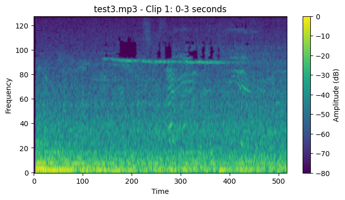

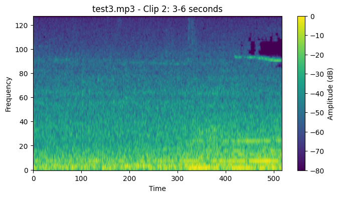

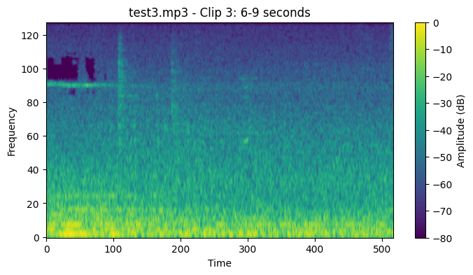

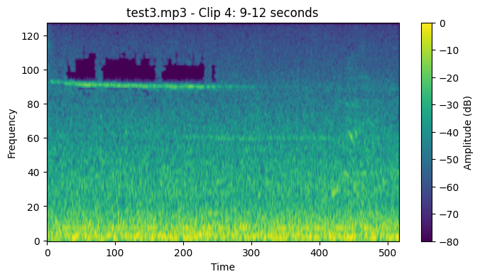

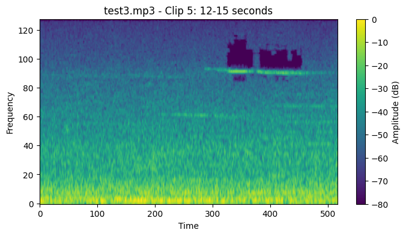

[output not shown]

```python
#Load the mp3 file of test3
file_path = "/Users/helenliu/Downloads/test3.mp3"
y_audio, sr = librosa.load(file_path)
print("Sample rate:", sr)
print("Audio length (seconds):", len(y_audio) / sr)

#split the audio into 3-second clips
window_seconds = 3
window_length = window_seconds * sr
test3_clips = []
for start in range(0, len(y_audio)-window_length+1, window_length):
    end = start + window_length
    small_clip = y_audio[start:end]
    test3_clips.append(small_clip)

print("Number of 3-second clips:", len(test3_clips))

#create spectrograms for each clip
test3_specs = []
for i, clip in enumerate(test3_clips):
    spec = librosa.feature.melspectrogram(
        y=clip,
        sr=sr,
        hop_length=128,
        win_length=512)
    spec_db = librosa.power_to_db(spec, ref=np.max)
    test3_specs.append(spec_db)
    print("Clip", i + 1, "spectrogram shape:", spec_db.shape)

    #plot spectrograms
for i, spec_db in enumerate(test3_specs):
    plt.figure(figsize=(8, 4))
    plt.imshow(spec_db, aspect="auto", origin="lower")
    plt.title(f"test3.mp3 - Clip {i + 1}: {i*3}-{(i+1)*3} seconds")
    plt.xlabel("Time")
    plt.ylabel("Frequency")
    plt.colorbar(label="Amplitude (dB)")
    plt.show()

#convert spectrograms
x_test3_external = np.array(test3_specs)
print("Before normalization:", x_test3_external.shape)

#normalize spectrograms to 0-1 range
x_test3_external_norm = []
for spec_db in x_test3_external:
    spec_norm = (spec_db - spec_db.min()) / (spec_db.max() - spec_db.min())
    x_test3_external_norm.append(spec_norm)
x_test3_external_norm = np.array(x_test3_external_norm)

#add channel dimension
x_test3_external_norm = x_test3_external_norm[..., np.newaxis]

print("CNN-ready shape:", x_test3_external_norm.shape)

#predict each small clip with the final model
model_multi_final = model_multi_8
pred_prob_test3 = model_multi_final.predict(x_test3_external_norm)
pred_class_test3 = np.argmax(pred_prob_test3, axis=1)
pred_species_test3 = [species_key_from_list[i] for i in pred_class_test3]

for i, species in enumerate(pred_species_test3):
    print(f"Clip {i + 1}: {i*3}-{(i+1)*3} sec")
    print("Predicted species:", species)
    print("Probability:", pred_prob_test3[i, pred_class_test3[i]])
    print()
```

Test clip 3 produced less consistent predictions across windows, although the 9–12 second window was strongly predicted as Song Sparrow (sonspa; probability = 0.937). This may reflect intermittent bird sound and background noise in the clip, which could make some windows harder for the model to classify confidently.